# CFA Attitude V1

Author

firdaus

# 1 Preliminaries

## 1.1 Load Library

```r
library(readxl)
library(foreign)
library(psych)
library(lavaan)  # for CFA
library(semTools)  # for additional functions in SEM
library(semPlot)  # for path diagram
```

## 1.2 Load Data

```r
data1 = read_excel("CFA_Attitude_V1.xlsx")
names(data1)
```

```
 [1] "A1"  "A2"  "A3"  "A4"  "A5"  "A6"  "A7"  "A8"  "A9"  "A10" "A11" "A12"
[13] "A13" "A14" "A15" "A16" "A17" "A18" "A19" "A20" "A21" "A22"
```

```r
head(data1)
```

```
# A tibble: 6 × 22
  A1     A2    A3    A4    A5    A6    A7    A8    A9    A10   A11   A12   A13
  <chr>  <chr> <chr> <chr> <chr> <chr> <chr> <chr> <chr> <chr> <chr> <chr> <chr>
1 Sanga… Sang… Sang… Sang… Sang… Sang… Tida… Tida… Tida… Tida… Tida… Tida… Tida…
2 Setuju Setu… Setu… Setu… Setu… Setu… Tida… Tida… Tida… Sang… Sang… Sang… Sang…
3 Sanga… Sang… Sang… Sang… Sang… Sang… Tida… Tida… Tida… Sang… Sang… Sang… Sang…
4 Sanga… Sang… Sang… Sang… Sang… Sang… Sang… Sang… Sang… Sang… Sang… Sang… Sang…
5 Setuju Setu… Setu… Setu… Setu… Setu… Tida… Tida… Tida… Tida… Tida… Tida… Tida…
6 Setuju Setu… Setu… Setu… Setu… Setu… Tida… Tida… Tida… Sang… Sang… Sang… Sang…
# ℹ 9 more variables: A14 <chr>, A15 <chr>, A16 <chr>, A17 <chr>, A18 <chr>,
#   A19 <chr>, A20 <chr>, A21 <chr>, A22 <chr>
```

```r
dim(data1)
```

```
[1] 201  22
```

### 1.2.1 Coding the answers

```r
# Define mapping functions
likert_map <- function(x) {
  recode <- c(
    "Sangat tidak setuju" = 1,
    "Tidak setuju"        = 2,
    "Tidak pasti"         = 3,
    "Setuju"              = 4,
    "Sangat setuju"       = 5
  )
  recode[match(tolower(x), tolower(names(recode)))]
}

likert_reverse <- function(x) {
  recode <- c(
    "Sangat tidak setuju" = 5,
    "Tidak setuju"        = 4,
    "Tidak pasti"         = 3,
    "Setuju"              = 2,
    "Sangat setuju"       = 1
  )
  recode[match(tolower(x), tolower(names(recode)))]
}

# List of reverse-coded items
reverse_items <- c("A7","A8","A9","A10","A11","A12","A13")

# Apply transformation from data1 -> data2
data2 <- data1

for (col in names(data2)) {
  if (col %in% reverse_items) {
    data2[[col]] <- likert_reverse(data2[[col]])
  } else {
    data2[[col]] <- likert_map(data2[[col]])
  }
}

# Convert all to numeric
data2 <- as.data.frame(lapply(data2, as.numeric))
```

From EFA, we include only good items across PA1 till PA4.

PA3 (Sex Ed Importance ) : A1, A2, A3, A4, A5, A6 (6 item)

PA2 (Sex Ed Concerns) : A7, A8, A9 (3 item)

PA4 (Soc Sensitivity): A10, A11, A12, A13 (4 item)

PA1 (Parent Role): A14, A15, A16, A17, A18, A19, A20, A21, A22 (9 item)

```r
data.cfa = data2[c("A1", "A2","A3", "A4", "A5", "A6", "A7", "A8", "A9", "A10", "A11", "A12", "A13", "A14", "A15", "A16", "A17", "A18", "A19", "A20", "A21", "A22")]
```

```r
str(data.cfa)
```

```
'data.frame':   201 obs. of  22 variables:
 $ A1 : num  5 4 5 5 4 4 5 4 4 5 ...
 $ A2 : num  5 4 5 5 4 4 5 4 4 5 ...
 $ A3 : num  5 4 5 5 4 4 5 4 4 5 ...
 $ A4 : num  5 4 5 5 4 4 5 4 4 5 ...
 $ A5 : num  5 4 5 5 4 4 5 4 4 5 ...
 $ A6 : num  5 4 5 5 4 4 5 4 4 5 ...
 $ A7 : num  3 4 3 1 3 3 1 4 3 3 ...
 $ A8 : num  3 4 3 1 3 3 1 3 3 3 ...
 $ A9 : num  3 4 3 1 3 3 3 3 3 3 ...
 $ A10: num  4 5 5 5 4 5 4 5 4 5 ...
 $ A11: num  4 5 5 5 4 5 4 5 4 5 ...
 $ A12: num  4 5 5 5 3 5 2 5 4 4 ...
 $ A13: num  4 5 5 5 4 5 3 5 4 4 ...
 $ A14: num  4 4 5 5 3 5 4 5 5 5 ...
 $ A15: num  4 3 5 5 4 5 4 5 5 5 ...
 $ A16: num  4 3 5 5 4 5 4 5 5 5 ...
 $ A17: num  4 3 5 5 4 5 4 5 5 5 ...
 $ A18: num  4 3 5 5 4 5 4 5 5 5 ...
 $ A19: num  5 4 5 5 4 5 5 5 5 5 ...
 $ A20: num  5 4 5 5 4 5 5 3 5 5 ...
 $ A21: num  5 4 5 5 4 4 5 5 4 5 ...
 $ A22: num  5 4 5 5 3 4 5 2 5 5 ...
```

```r
dim(data.cfa)
```

```
[1] 201  22
```

```r
names(data.cfa)
```

```
 [1] "A1"  "A2"  "A3"  "A4"  "A5"  "A6"  "A7"  "A8"  "A9"  "A10" "A11" "A12"
[13] "A13" "A14" "A15" "A16" "A17" "A18" "A19" "A20" "A21" "A22"
```

```r
head(data.cfa)
```

```
  A1 A2 A3 A4 A5 A6 A7 A8 A9 A10 A11 A12 A13 A14 A15 A16 A17 A18 A19 A20 A21
1  5  5  5  5  5  5  3  3  3   4   4   4   4   4   4   4   4   4   5   5   5
2  4  4  4  4  4  4  4  4  4   5   5   5   5   4   3   3   3   3   4   4   4
3  5  5  5  5  5  5  3  3  3   5   5   5   5   5   5   5   5   5   5   5   5
4  5  5  5  5  5  5  1  1  1   5   5   5   5   5   5   5   5   5   5   5   5
5  4  4  4  4  4  4  3  3  3   4   4   3   4   3   4   4   4   4   4   4   4
6  4  4  4  4  4  4  3  3  3   5   5   5   5   5   5   5   5   5   5   5   4
  A22
1   5
2   4
3   5
4   5
5   3
6   4
```

# 2 Confirmatory factor analysis

## 2.1 Preliminary steps

### 2.1.1 **Descriptive statistics**

Check minimum/maximum values per item, and screen for any missing values,

```r
describe(data.cfa)
```

```
    vars   n mean   sd median trimmed  mad min max range  skew kurtosis   se
A1     1 201 4.15 1.11      4    4.40 1.48   1   5     4 -1.74     2.57 0.08
A2     2 201 4.07 1.13      4    4.30 1.48   1   5     4 -1.48     1.61 0.08
A3     3 201 4.16 1.12      4    4.42 1.48   1   5     4 -1.75     2.51 0.08
A4     4 201 4.16 1.10      4    4.40 1.48   1   5     4 -1.72     2.47 0.08
A5     5 201 4.18 1.10      4    4.43 1.48   1   5     4 -1.78     2.62 0.08
A6     6 201 4.15 1.13      4    4.41 1.48   1   5     4 -1.68     2.17 0.08
A7     7 201 3.25 1.02      3    3.27 1.48   1   5     4 -0.32    -0.55 0.07
A8     8 201 3.30 0.99      3    3.31 1.48   1   5     4 -0.29    -0.55 0.07
A9     9 201 3.44 0.96      3    3.47 1.48   1   5     4 -0.33    -0.20 0.07
A10   10 201 4.06 1.01      4    4.23 1.48   1   5     4 -1.08     0.58 0.07
A11   11 201 4.10 0.99      4    4.27 1.48   1   5     4 -1.14     0.71 0.07
A12   12 201 3.60 1.11      4    3.67 1.48   1   5     4 -0.63    -0.55 0.08
A13   13 201 3.70 1.12      4    3.80 1.48   1   5     4 -0.77    -0.35 0.08
A14   14 201 4.46 0.67      5    4.55 0.00   1   5     4 -1.45     3.56 0.05
A15   15 201 4.51 0.68      5    4.60 0.00   1   5     4 -1.89     6.01 0.05
A16   16 201 4.51 0.66      5    4.58 0.00   1   5     4 -1.71     4.96 0.05
A17   17 201 4.43 0.72      5    4.52 0.00   1   5     4 -1.80     5.25 0.05
A18   18 201 4.45 0.68      5    4.53 0.00   1   5     4 -1.51     3.86 0.05
A19   19 201 4.46 0.62      5    4.52 0.00   2   5     3 -1.07     1.88 0.04
A20   20 201 4.44 0.63      4    4.49 1.48   1   5     4 -1.39     4.47 0.04
A21   21 201 4.45 0.69      5    4.54 0.00   1   5     4 -1.59     3.99 0.05
A22   22 201 4.36 0.72      4    4.45 1.48   1   5     4 -1.52     4.18 0.05
```

% of response to options per item,

```r
response.frequencies(data.cfa)
```

```
              1           2          3         4          5 miss
A1  0.079601990 0.004975124 0.04975124 0.4129353 0.45273632    0
A2  0.074626866 0.024875622 0.07960199 0.3980100 0.42288557    0
A3  0.079601990 0.014925373 0.02985075 0.4179104 0.45771144    0
A4  0.074626866 0.014925373 0.04477612 0.4079602 0.45771144    0
A5  0.074626866 0.019900498 0.02487562 0.4129353 0.46766169    0
A6  0.079601990 0.019900498 0.03980100 0.3930348 0.46766169    0
A7  0.049751244 0.189054726 0.30348259 0.3731343 0.08457711    0
A8  0.034825871 0.189054726 0.30348259 0.3830846 0.08955224    0
A9  0.029850746 0.119402985 0.35323383 0.3731343 0.12437811    0
A10 0.019900498 0.084577114 0.10447761 0.3930348 0.39800995    0
A11 0.014925373 0.089552239 0.07960199 0.4079602 0.40796020    0
A12 0.039800995 0.179104478 0.12437811 0.4577114 0.19900498    0
A13 0.039800995 0.164179104 0.08955224 0.4726368 0.23383085    0
A14 0.004975124 0.009950249 0.03980100 0.4079602 0.53731343    0
A15 0.009950249 0.004975124 0.02985075 0.3781095 0.57711443    0
A16 0.004975124 0.014925373 0.01492537 0.3980100 0.56716418    0
A17 0.009950249 0.019900498 0.01492537 0.4427861 0.51243781    0
A18 0.004975124 0.014925373 0.02985075 0.4228856 0.52736318    0
A19 0.000000000 0.014925373 0.01990050 0.4527363 0.51243781    0
A20 0.004975124 0.009950249 0.01492537 0.4776119 0.49253731    0
A21 0.004975124 0.019900498 0.02487562 0.4179104 0.53233831    0
A22 0.009950249 0.014925373 0.03980100 0.4776119 0.45771144    0
```

### 2.1.2 **Multivariate normality**

This is done to check the multivariate normality of the data. If the data are normally distributed, we may use maximum likelihood (ML) estimation method for the CFA.

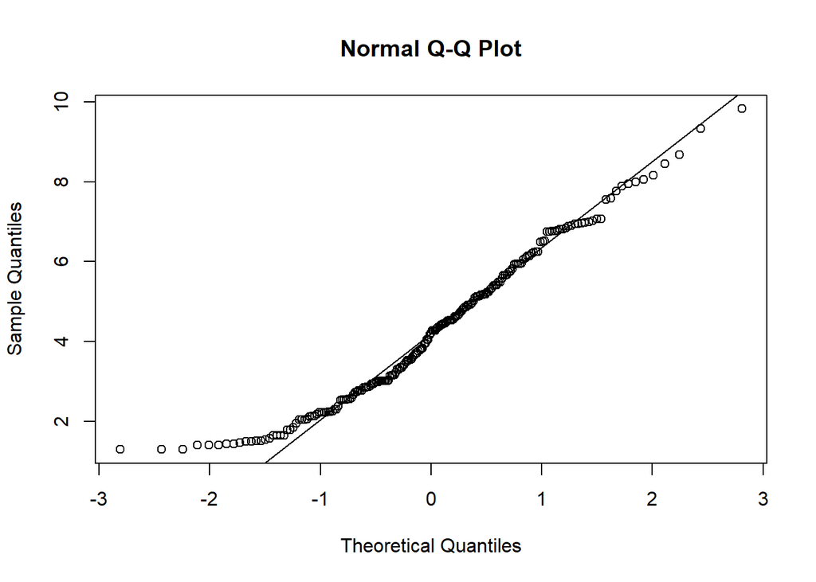

```
Call: mardia(x = data.cfa)

Mardia tests of multivariate skew and kurtosis
Use describe(x) the to get univariate tests
n.obs = 201   num.vars =  22
b1p =  209.61   skew =  7021.93  with probability  <=  0
 small sample skew =  7135.95  with probability <=  0
b2p =  818.5   kurtosis =  63.37  with probability <=  0
```

```r
mardia(data.cfa)
```

the data are not multivariate normal (`kurtosis` > 5, *P* < 0.05). We will use **MLR** in our analysis.

## 2.2 Step 1

Specify the measurement model according to `lavaan` syntax.

```r
model1 = "
PA1 =~ A14 + A15 + A16 + A17 + A18 + A19 + A20 + A21 + A22
PA2 =~ A7 + A8 + A9
PA3 =~ A1 + A2 + A3 + A4 + A5 + A6
PA4 =~ A10 + A11 + A12 + A13
"
```

PA3 (Sex Ed Importance ) : A1, A2, A3, A4, A5, A6 (6 item)

PA2 (Sex Ed Concerns) : A7, A8, A9 (3 item)

PA4 (Soc Sensitivity): A10, A11, A12, A13 (4 item)

PA1 (Parent Role): A14, A15, A16, A17, A18, A19, A20, A21, A22 (9 item)

## 2.3 Step 2

### 2.3.1 Fit the model 1

```r
cfa.model1 = cfa(model1, data = data.cfa, estimator = "MLR")
# cfa.model = cfa(model, data = data.cfa, std.lv = 1)  # factor variance = 1
summary(cfa.model1, fit.measures = T, standardized = T)
```

```
lavaan 0.6-20 ended normally after 79 iterations

  Estimator                                         ML
  Optimization method                           NLMINB
  Number of model parameters                        50

  Number of observations                           201

Model Test User Model:
                                              Standard      Scaled
  Test Statistic                              1025.664     756.878
  Degrees of freedom                               203         203
  P-value (Chi-square)                           0.000       0.000
  Scaling correction factor                                  1.355
    Yuan-Bentler correction (Mplus variant)

Model Test Baseline Model:

  Test statistic                              6313.396    4117.840
  Degrees of freedom                               231         231
  P-value                                        0.000       0.000
  Scaling correction factor                                  1.533

User Model versus Baseline Model:

  Comparative Fit Index (CFI)                    0.865       0.857
  Tucker-Lewis Index (TLI)                       0.846       0.838

  Robust Comparative Fit Index (CFI)                         0.874
  Robust Tucker-Lewis Index (TLI)                            0.857

Loglikelihood and Information Criteria:

  Loglikelihood user model (H0)              -3071.545   -3071.545
  Scaling correction factor                                  2.545
      for the MLR correction
  Loglikelihood unrestricted model (H1)      -2558.713   -2558.713
  Scaling correction factor                                  1.590
      for the MLR correction

```

[output cut: 82 more lines]

```
   .A9                0.277    0.059    4.711    0.000    0.277    0.303
   .A1                0.117    0.028    4.128    0.000    0.117    0.097
   .A2                0.141    0.032    4.403    0.000    0.141    0.111
   .A3                0.063    0.016    4.043    0.000    0.063    0.051
   .A4                0.038    0.012    3.073    0.002    0.038    0.032
   .A5                0.038    0.012    3.222    0.001    0.038    0.031
   .A6                0.085    0.025    3.346    0.001    0.085    0.066
   .A10               0.146    0.053    2.775    0.006    0.146    0.144
   .A11               0.023    0.015    1.507    0.132    0.023    0.024
   .A12               0.812    0.122    6.653    0.000    0.812    0.658
   .A13               0.889    0.127    6.987    0.000    0.889    0.714
    PA1               0.377    0.075    5.047    0.000    1.000    1.000
    PA2               0.716    0.094    7.640    0.000    1.000    1.000
    PA3               1.098    0.186    5.888    0.000    1.000    1.000
    PA4               0.869    0.106    8.184    0.000    1.000    1.000
```

```r
standardizedSolution(cfa.model1)  # standardized, to view the SE of FL
```

```
   lhs op rhs est.std    se       z pvalue ci.lower ci.upper
1  PA1 =~ A14   0.917 0.023  40.197  0.000    0.873    0.962
2  PA1 =~ A15   0.940 0.019  49.111  0.000    0.903    0.978
3  PA1 =~ A16   0.936 0.018  51.476  0.000    0.900    0.972
4  PA1 =~ A17   0.896 0.035  25.883  0.000    0.828    0.964
5  PA1 =~ A18   0.876 0.041  21.578  0.000    0.796    0.955
6  PA1 =~ A19   0.727 0.067  10.785  0.000    0.595    0.859
7  PA1 =~ A20   0.714 0.076   9.433  0.000    0.566    0.863
8  PA1 =~ A21   0.736 0.065  11.257  0.000    0.608    0.864
9  PA1 =~ A22   0.739 0.068  10.843  0.000    0.605    0.873
10 PA2 =~  A7   0.832 0.036  23.318  0.000    0.762    0.902
11 PA2 =~  A8   0.990 0.013  74.953  0.000    0.964    1.016
12 PA2 =~  A9   0.835 0.040  20.632  0.000    0.756    0.914
13 PA3 =~  A1   0.950 0.015  65.545  0.000    0.922    0.979
14 PA3 =~  A2   0.943 0.016  60.002  0.000    0.912    0.974
```

[output cut: 40 more lines]

```r
parameterEstimates(cfa.model1)  # unstandardized, to view the 95% CI
```

```
   lhs op rhs   est    se      z pvalue ci.lower ci.upper
1  PA1 =~ A14 1.000 0.000     NA     NA    1.000    1.000
2  PA1 =~ A15 1.038 0.045 23.190  0.000    0.950    1.125
3  PA1 =~ A16 0.999 0.041 24.184  0.000    0.918    1.080
4  PA1 =~ A17 1.046 0.064 16.263  0.000    0.920    1.172
5  PA1 =~ A18 0.964 0.051 18.764  0.000    0.864    1.065
6  PA1 =~ A19 0.729 0.121  6.011  0.000    0.491    0.966
7  PA1 =~ A20 0.732 0.138  5.309  0.000    0.462    1.003
8  PA1 =~ A21 0.828 0.068 12.186  0.000    0.695    0.961
9  PA1 =~ A22 0.867 0.079 11.011  0.000    0.713    1.021
10 PA2 =~  A7 1.000 0.000     NA     NA    1.000    1.000
11 PA2 =~  A8 1.156 0.052 22.131  0.000    1.054    1.259
12 PA2 =~  A9 0.943 0.067 14.076  0.000    0.811    1.074
13 PA3 =~  A1 1.000 0.000     NA     NA    1.000    1.000
14 PA3 =~  A2 1.014 0.021 48.532  0.000    0.973    1.055
```

[output cut: 40 more lines]

Localized areas of misfit,

```r
modificationIndices(cfa.model1, sort = TRUE, minimum.value = 3.84) # find mi > |3.84|
```

```
    lhs op rhs      mi    epc sepc.lv sepc.all sepc.nox
351 A12 ~~ A13 149.293  0.748   0.748    0.879    0.879
346 A10 ~~ A11 140.475  1.346   1.346   23.086   23.086
307  A1 ~~  A2  83.833  0.091   0.091    0.709    0.709
216 A19 ~~ A20  77.885  0.120   0.120    0.645    0.645
247 A21 ~~ A22  60.739  0.130   0.130    0.572    0.572
181 A17 ~~ A18  58.566  0.065   0.065    0.628    0.628
121 A14 ~~ A15  46.271  0.041   0.041    0.671    0.671
318  A2 ~~  A5  36.387 -0.040  -0.040   -0.551   -0.551
310  A1 ~~  A5  27.278 -0.032  -0.032   -0.486   -0.486
233 A20 ~~ A22  19.990  0.070   0.070    0.327    0.327
337  A5 ~~  A6  17.981  0.024   0.024    0.421    0.421
146 A15 ~~ A20  14.917 -0.033  -0.033   -0.323   -0.323
126 A14 ~~ A20  14.572 -0.036  -0.036   -0.303   -0.303
217 A19 ~~ A21  14.483  0.055   0.055    0.279    0.279
```

[output cut: 50 more lines]

```r
residuals(cfa.model1, type="standardized") # find sr > |2.58|
```

```
$type
[1] "standardized"

$cov
       A14    A15    A16    A17    A18    A19    A20    A21    A22     A7
A14  0.000
A15  0.910  0.000
A16  0.400  0.411  0.000
A17 -0.247 -0.156 -0.673  0.000
A18 -0.638 -0.664 -0.037  1.674  0.000
A19 -1.357 -0.867  0.182 -0.117 -0.822  0.000
A20 -1.034 -0.821 -0.463  0.301  0.526  3.394  0.000
A21 -1.783 -1.051 -0.265 -0.095 -0.328  2.222  0.897  0.000
A22 -0.597 -0.505 -0.663 -0.265 -0.174  1.350  1.620  3.978  0.000
A7   1.497  1.598  0.533  0.761  0.665  0.731 -0.211 -0.116  0.322  0.000
A8   0.214  0.032 -0.628  0.382  0.382 -0.026  0.002 -0.677 -0.327  0.000
A9   0.168  0.130  0.193 -0.365 -0.656  0.323 -0.671 -0.586 -0.656 -0.022
A1  -0.058 -0.692  0.087 -1.315 -1.461  1.178  0.104  1.373  0.092 -0.078
A2  -0.036 -0.811  0.429 -1.027 -1.284  2.123  1.365  2.105  1.123  0.602
A3   0.451  0.576  0.737  0.313 -0.599  2.013  1.094  1.737  0.996 -0.899
A4  -1.086 -0.910 -0.434 -1.037 -1.375  1.356  0.515  1.921  0.378 -0.814
A5  -0.803 -0.636  0.446 -0.698 -0.880  1.695  0.777  2.098  0.329 -1.019
A6  -0.399 -0.378  0.237 -0.570 -0.163  1.434  1.588  1.445  0.530 -0.642
A10 -0.714 -1.039 -0.634  0.066  0.565 -0.103  1.129 -0.258  0.067 -0.069
A11 -0.375 -0.769  0.095  0.242  0.985  0.030  0.860  0.173  0.061  0.376
A12  0.517  0.313  0.593  0.253  0.875  0.403  1.048 -0.199 -0.171  1.924
A13  1.166  0.562  0.990  0.330  1.004  0.560  0.078 -0.135 -0.183  2.891
        A8     A9     A1     A2     A3     A4     A5     A6    A10    A11
A14
A15
A16
A17
A18
A19
A20
A21
A22
A7
A8   0.000
A9   0.002  0.000
```

[output cut: 18 more lines]

```
A21
A22
A7
A8
A9
A1
A2
A3
A4
A5
A6
A10
A11
A12  0.000
A13  5.080  0.000
```

## 2.4 Step 3

### 2.4.1 Refine Model 2

```r
# Step 1: Add strongest correlated residuals
model2 <- '
  PA1 =~ A14 + A15 + A16 + A17 + A18 + A19 + A20 + A21 + A22
  PA2 =~ A7 + A8 + A9
  PA3 =~ A1 + A2 + A3 + A4 + A5 + A6
  PA4 =~ A10 + A11 + A12 + A13

  # Correlated residuals (theoretically justified)
  A12 ~~ A13
'


cfa.model2 = cfa(model2, data = data.cfa, estimator = "MLR")
# cfa.model = cfa(model, data = data.cfa, std.lv = 1)  # factor variance = 1
summary(cfa.model2, fit.measures = T, standardized = T)
```

```
lavaan 0.6-20 ended normally after 96 iterations

  Estimator                                         ML
  Optimization method                           NLMINB
  Number of model parameters                        51

  Number of observations                           201

Model Test User Model:
                                              Standard      Scaled
  Test Statistic                               771.515     571.994
  Degrees of freedom                               202         202
  P-value (Chi-square)                           0.000       0.000
  Scaling correction factor                                  1.349
    Yuan-Bentler correction (Mplus variant)

Model Test Baseline Model:

  Test statistic                              6313.396    4117.840
  Degrees of freedom                               231         231
  P-value                                        0.000       0.000
  Scaling correction factor                                  1.533

User Model versus Baseline Model:

  Comparative Fit Index (CFI)                    0.906       0.905
  Tucker-Lewis Index (TLI)                       0.893       0.891

  Robust Comparative Fit Index (CFI)                         0.916
  Robust Tucker-Lewis Index (TLI)                            0.904

Loglikelihood and Information Criteria:

  Loglikelihood user model (H0)              -2944.470   -2944.470
  Scaling correction factor                                  2.547
      for the MLR correction
  Loglikelihood unrestricted model (H1)      -2558.713   -2558.713
  Scaling correction factor                                  1.590
      for the MLR correction

```

[output cut: 84 more lines]

```
   .A9                0.277    0.059    4.711    0.000    0.277    0.303
   .A1                0.117    0.028    4.128    0.000    0.117    0.097
   .A2                0.141    0.032    4.403    0.000    0.141    0.111
   .A3                0.063    0.016    4.043    0.000    0.063    0.051
   .A4                0.038    0.012    3.073    0.002    0.038    0.031
   .A5                0.038    0.012    3.223    0.001    0.038    0.031
   .A6                0.085    0.025    3.346    0.001    0.085    0.066
   .A10               0.179    0.071    2.527    0.012    0.179    0.177
   .A11              -0.019    0.032   -0.580    0.562   -0.019   -0.019
   .A12               0.843    0.117    7.224    0.000    0.843    0.682
   .A13               0.911    0.121    7.554    0.000    0.911    0.731
    PA1               0.377    0.075    5.047    0.000    1.000    1.000
    PA2               0.717    0.094    7.639    0.000    1.000    1.000
    PA3               1.098    0.186    5.888    0.000    1.000    1.000
    PA4               0.836    0.110    7.621    0.000    1.000    1.000
```

```r
modificationIndices(cfa.model2, sort = TRUE, minimum.value = 3.84) # find mi > |3.84|
```

```
    lhs op rhs     mi    epc sepc.lv sepc.all sepc.nox
308  A1 ~~  A2 83.834  0.091   0.091    0.709    0.709
217 A19 ~~ A20 77.906  0.120   0.120    0.646    0.646
248 A21 ~~ A22 60.738  0.130   0.130    0.572    0.572
182 A17 ~~ A18 58.611  0.065   0.065    0.628    0.628
122 A14 ~~ A15 46.234  0.041   0.041    0.671    0.671
319  A2 ~~  A5 36.391 -0.040  -0.040   -0.551   -0.551
311  A1 ~~  A5 27.288 -0.032  -0.032   -0.486   -0.486
234 A20 ~~ A22 20.014  0.070   0.070    0.328    0.328
338  A5 ~~  A6 17.982  0.024   0.024    0.421    0.421
147 A15 ~~ A20 14.869 -0.033  -0.033   -0.322   -0.322
127 A14 ~~ A20 14.518 -0.035  -0.035   -0.302   -0.302
218 A19 ~~ A21 14.482  0.055   0.055    0.279    0.279
126 A14 ~~ A19 13.517 -0.033  -0.033   -0.293   -0.293
296  A8 ~~ A12 13.329  0.055   0.055    0.424    0.424
```

[output cut: 61 more lines]

```r
residuals(cfa.model2, type="standardized") # find sr > |2.58|
```

```
$type
[1] "standardized"

$cov
       A14    A15    A16    A17    A18    A19    A20    A21    A22     A7
A14  0.000
A15  0.933  0.000
A16  0.448  0.406  0.000
A17 -0.253 -0.151 -0.669  0.000
A18 -0.717 -0.680 -0.042  1.705  0.000
A19 -1.346 -0.874  0.180 -0.115 -0.821  0.000
A20 -0.915 -0.699 -0.399  0.264  0.478  3.355  0.000
A21 -1.867 -1.017 -0.279 -0.092 -0.327  2.208  0.818  0.000
A22 -0.607 -0.502 -0.664 -0.265 -0.177  1.338  1.566  4.035  0.000
A7   1.621  1.742  0.591  0.837  0.723  0.759 -0.221 -0.125  0.342  0.000
A8   0.261  0.041 -0.796  0.497  0.464 -0.027  0.003 -0.749 -0.362  0.000
A9   0.187  0.143  0.222 -0.399 -0.735  0.334 -0.679 -0.621 -0.685 -0.036
A1  -0.061 -0.704  0.091 -1.334 -1.504  1.194  0.101  1.389  0.095 -0.090
A2  -0.038 -0.851  0.455 -1.057 -1.316  2.128  1.319  2.149  1.148  0.688
A3   0.464  0.606  0.771  0.324 -0.605  1.986  1.108  1.775  0.999 -1.049
A4  -1.157 -0.929 -0.459 -1.053 -1.428  1.369  0.489  1.925  0.385 -0.951
A5  -0.839 -0.666  0.474 -0.718 -0.899  1.696  0.752  2.133  0.332 -1.196
A6  -0.407 -0.397  0.246 -0.587 -0.164  1.419  1.593  1.473  0.533 -0.739
A10 -0.570 -0.860 -0.508  0.176  0.650 -0.025  1.221 -0.191  0.155  0.118
A11 -0.395 -0.772  0.031  0.167  0.861 -0.006  0.830  0.138  0.017  0.455
A12  0.697  0.476  0.771  0.369  0.994  0.507  1.111 -0.107 -0.074  2.170
A13  1.488  0.799  1.343  0.508  1.346  0.732  0.163 -0.084 -0.145  2.972
        A8     A9     A1     A2     A3     A4     A5     A6    A10    A11
A14
A15
A16
A17
A18
A19
A20
A21
A22
A7
A8   0.000
A9   0.002  0.000
```

[output cut: 18 more lines]

```
A21
A22
A7
A8
A9
A1
A2
A3
A4
A5
A6
A10
A11
A12  0.000
A13  0.000  0.000
```

### 2.4.2 Refine Model 3 (Remove A11)

```r
model3 <- '
  # Factors
  PA1 =~ A14 + A15 + A16 + A17 + A18 + A19 + A20 + A21 + A22
  PA2 =~ A7  + A8  + A9
  PA3 =~ A1  + A2  + A3  + A4  + A5  + A6

  #remove A11
  PA4 =~ A10 + A12 + A13

  # Correlated residuals (theoretically justified)
  A12 ~~ A13
 '

cfa.model3 = cfa(model3, data = data.cfa, estimator = "MLR")
# cfa.model = cfa(model, data = data.cfa, std.lv = 1)  # factor variance = 1
summary(cfa.model3, fit.measures = T, standardized = T)
```

```
lavaan 0.6-20 ended normally after 98 iterations

  Estimator                                         ML
  Optimization method                           NLMINB
  Number of model parameters                        49

  Number of observations                           201

Model Test User Model:
                                              Standard      Scaled
  Test Statistic                               738.999     534.706
  Degrees of freedom                               182         182
  P-value (Chi-square)                           0.000       0.000
  Scaling correction factor                                  1.382
    Yuan-Bentler correction (Mplus variant)

Model Test Baseline Model:

  Test statistic                              5899.876    3846.757
  Degrees of freedom                               210         210
  P-value                                        0.000       0.000
  Scaling correction factor                                  1.534

User Model versus Baseline Model:

  Comparative Fit Index (CFI)                    0.902       0.903
  Tucker-Lewis Index (TLI)                       0.887       0.888

  Robust Comparative Fit Index (CFI)                         0.913
  Robust Tucker-Lewis Index (TLI)                            0.899

Loglikelihood and Information Criteria:

  Loglikelihood user model (H0)              -2852.911   -2852.911
  Scaling correction factor                                  2.395
      for the MLR correction
  Loglikelihood unrestricted model (H1)      -2483.412   -2483.412
  Scaling correction factor                                  1.597
      for the MLR correction

```

[output cut: 82 more lines]

```
   .A8                0.016    0.026    0.596    0.551    0.016    0.016
   .A9                0.279    0.060    4.674    0.000    0.279    0.306
   .A1                0.117    0.028    4.128    0.000    0.117    0.097
   .A2                0.141    0.032    4.403    0.000    0.141    0.111
   .A3                0.063    0.016    4.044    0.000    0.063    0.051
   .A4                0.038    0.012    3.072    0.002    0.038    0.032
   .A5                0.038    0.012    3.222    0.001    0.038    0.031
   .A6                0.085    0.025    3.346    0.001    0.085    0.066
   .A10               0.601    0.189    3.183    0.001    0.601    0.592
   .A12               0.431    0.204    2.110    0.035    0.431    0.349
   .A13               0.591    0.198    2.980    0.003    0.591    0.475
    PA1               0.377    0.075    5.055    0.000    1.000    1.000
    PA2               0.714    0.094    7.600    0.000    1.000    1.000
    PA3               1.098    0.186    5.888    0.000    1.000    1.000
    PA4               0.415    0.151    2.753    0.006    1.000    1.000
```

```r
modificationIndices(cfa.model3, sort = TRUE, minimum.value = 3.84) # find mi > |3.84|
```

```
    lhs op rhs     mi    epc sepc.lv sepc.all sepc.nox
291  A1 ~~  A2 83.857  0.091   0.091    0.709    0.709
207 A19 ~~ A20 77.937  0.120   0.120    0.646    0.646
236 A21 ~~ A22 60.859  0.130   0.130    0.573    0.573
174 A17 ~~ A18 58.840  0.065   0.065    0.629    0.629
117 A14 ~~ A15 45.708  0.041   0.041    0.668    0.668
301  A2 ~~  A5 36.393 -0.040  -0.040   -0.551   -0.551
294  A1 ~~  A5 27.272 -0.032  -0.032   -0.486   -0.486
223 A20 ~~ A22 20.072  0.070   0.070    0.328    0.328
317  A5 ~~  A6 17.938  0.024   0.024    0.421    0.421
141 A15 ~~ A20 14.978 -0.033  -0.033   -0.324   -0.324
122 A14 ~~ A20 14.617 -0.036  -0.036   -0.304   -0.304
208 A19 ~~ A21 14.552  0.055   0.055    0.280    0.280
121 A14 ~~ A19 13.666 -0.033  -0.033   -0.294   -0.294
271  A7 ~~ A13 12.864  0.074   0.074    0.169    0.169
```

[output cut: 50 more lines]

```r
residuals(cfa.model3, type="standardized") # find sr > |2.58|
```

```
$type
[1] "standardized"

$cov
       A14    A15    A16    A17    A18    A19    A20    A21    A22     A7
A14  0.000
A15  0.832  0.000
A16  0.402  0.352  0.000
A17 -0.231 -0.137 -0.595  0.000
A18 -0.687 -0.618 -0.031  1.626  0.000
A19 -1.356 -0.814  0.173 -0.106 -0.801  0.000
A20 -0.936 -0.704 -0.402  0.271  0.497  3.321  0.000
A21 -2.029 -0.977 -0.292 -0.081 -0.324  2.298  0.842  0.000
A22 -0.578 -0.461 -0.610 -0.241 -0.162  1.348  1.606  4.112  0.000
A7   1.643  1.755  0.617  0.858  0.745  0.784 -0.220 -0.119  0.367  0.000
A8   0.292  0.061 -0.852  0.586  0.532 -0.019  0.011 -0.786 -0.382 -0.004
A9   0.215  0.169  0.268 -0.412 -0.793  0.351 -0.695 -0.640 -0.702  0.029
A1  -0.063 -0.663  0.093 -1.271 -1.485  1.222  0.105  1.408  0.097 -0.084
A2  -0.040 -0.804  0.458 -0.987 -1.277  2.215  1.379  2.202  1.173  0.729
A3   0.492  0.643  0.825  0.335 -0.618  2.104  1.139  1.807  1.037 -1.106
A4  -1.119 -0.852 -0.448 -0.972 -1.377  1.392  0.504  1.935  0.386 -0.999
A5  -0.879 -0.662  0.500 -0.693 -0.902  1.762  0.774  2.152  0.340 -1.269
A6  -0.427 -0.419  0.262 -0.581 -0.161  1.493  1.626  1.514  0.552 -0.774
A10  0.641  0.462  0.689  1.515  2.081  0.837  2.097  0.521  1.094 -0.445
A12 -0.558 -1.171 -0.438 -0.937  0.029 -0.287  0.311 -0.923 -0.978  0.677
A13  0.643 -0.209  0.462 -0.413  0.515  0.086 -0.423 -0.832 -0.848  2.298
        A8     A9     A1     A2     A3     A4     A5     A6    A10    A12
A14
A15
A16
A17
A18
A19
A20
A21
A22
A7
A8   0.000
A9   0.005  0.000
A1   0.536  1.074  0.000
```

[output cut: 15 more lines]

```
A20
A21
A22
A7
A8
A9
A1
A2
A3
A4
A5
A6
A10
A12
A13  0.000
```

### 2.4.3 Refine Model 4

```r
model4 <- '
  # Factors
  PA1 =~ A14 + A15 + A16 + A17 + A18 + A19 + A20 + A21 + A22
  PA2 =~ A7  + A8  + A9
  PA3 =~ A1  + A2  + A3  + A4  + A5  + A6

  #remove A11
  PA4 =~ A10 + A12 + A13


  # Correlated residuals (theoretically justified)
  A12 ~~ A13
  A1 ~~ A2
'

cfa.model4 = cfa(model4, data = data.cfa, estimator = "MLR")
# cfa.model = cfa(model, data = data.cfa, std.lv = 1)  # factor variance = 1
summary(cfa.model4, fit.measures = T, standardized = T)
```

```
lavaan 0.6-20 ended normally after 108 iterations

  Estimator                                         ML
  Optimization method                           NLMINB
  Number of model parameters                        50

  Number of observations                           201

Model Test User Model:
                                              Standard      Scaled
  Test Statistic                               642.808     468.869
  Degrees of freedom                               181         181
  P-value (Chi-square)                           0.000       0.000
  Scaling correction factor                                  1.371
    Yuan-Bentler correction (Mplus variant)

Model Test Baseline Model:

  Test statistic                              5899.876    3846.757
  Degrees of freedom                               210         210
  P-value                                        0.000       0.000
  Scaling correction factor                                  1.534

User Model versus Baseline Model:

  Comparative Fit Index (CFI)                    0.919       0.921
  Tucker-Lewis Index (TLI)                       0.906       0.908

  Robust Comparative Fit Index (CFI)                         0.929
  Robust Tucker-Lewis Index (TLI)                            0.918

Loglikelihood and Information Criteria:

  Loglikelihood user model (H0)              -2804.816   -2804.816
  Scaling correction factor                                  2.415
      for the MLR correction
  Loglikelihood unrestricted model (H1)      -2483.412   -2483.412
  Scaling correction factor                                  1.597
      for the MLR correction

```

[output cut: 84 more lines]

```
   .A8                0.016    0.026    0.596    0.551    0.016    0.016
   .A9                0.279    0.060    4.674    0.000    0.279    0.306
   .A1                0.135    0.031    4.421    0.000    0.135    0.111
   .A2                0.162    0.034    4.731    0.000    0.162    0.128
   .A3                0.062    0.016    3.944    0.000    0.062    0.050
   .A4                0.041    0.014    2.949    0.003    0.041    0.034
   .A5                0.030    0.010    2.951    0.003    0.030    0.024
   .A6                0.082    0.025    3.297    0.001    0.082    0.064
   .A10               0.602    0.189    3.188    0.001    0.602    0.592
   .A12               0.430    0.205    2.097    0.036    0.430    0.348
   .A13               0.591    0.199    2.970    0.003    0.591    0.474
    PA1               0.377    0.075    5.054    0.000    1.000    1.000
    PA2               0.714    0.094    7.598    0.000    1.000    1.000
    PA3               1.080    0.187    5.778    0.000    1.000    1.000
    PA4               0.414    0.150    2.751    0.006    1.000    1.000
```

```r
modificationIndices(cfa.model4, sort = TRUE, minimum.value = 3.84) # find mi > |3.84|
```

```
    lhs op rhs     mi    epc sepc.lv sepc.all sepc.nox
208 A19 ~~ A20 77.932  0.120   0.120    0.646    0.646
237 A21 ~~ A22 60.860  0.130   0.130    0.573    0.573
175 A17 ~~ A18 58.803  0.065   0.065    0.629    0.629
118 A14 ~~ A15 45.771  0.041   0.041    0.669    0.669
224 A20 ~~ A22 20.071  0.070   0.070    0.328    0.328
142 A15 ~~ A20 14.986 -0.033  -0.033   -0.324   -0.324
123 A14 ~~ A20 14.596 -0.036  -0.036   -0.303   -0.303
209 A19 ~~ A21 14.549  0.055   0.055    0.280    0.280
122 A14 ~~ A19 13.640 -0.033  -0.033   -0.294   -0.294
272  A7 ~~ A13 12.865  0.074   0.074    0.169    0.169
140 A15 ~~ A18 12.486 -0.024  -0.024   -0.321   -0.321
157 A16 ~~ A17 12.147 -0.024  -0.024   -0.321   -0.321
138 A15 ~~ A16 11.984  0.020   0.020    0.369    0.369
281  A8 ~~ A12 10.481  0.049   0.049    0.599    0.599
```

[output cut: 54 more lines]

```r
residuals(cfa.model4, type="standardized") # find sr > |2.58|
```

```
$type
[1] "standardized"

$cov
       A14    A15    A16    A17    A18    A19    A20    A21    A22     A7
A14  0.000
A15  0.838  0.000
A16  0.387  0.360  0.000
A17 -0.224 -0.141 -0.586  0.000
A18 -0.706 -0.680 -0.034  1.678  0.000
A19 -1.339 -0.812  0.177 -0.106 -0.808  0.000
A20 -0.896 -0.693 -0.386  0.263  0.496  3.264  0.000
A21 -2.072 -1.012 -0.295 -0.083 -0.333  2.346  0.832  0.000
A22 -0.547 -0.449 -0.580 -0.230 -0.159  1.337  1.562  4.058  0.000
A7   1.669  1.773  0.629  0.878  0.756  0.795 -0.225 -0.121  0.374  0.000
A8   0.312  0.064 -0.896  0.613  0.548 -0.019  0.011 -0.791 -0.386 -0.004
A9   0.219  0.169  0.270 -0.409 -0.798  0.351 -0.688 -0.635 -0.694  0.031
A1   0.027 -0.593  0.176 -1.188 -1.407  1.308  0.139  1.486  0.145 -0.037
A2   0.056 -0.710  0.575 -0.884 -1.169  2.245  1.363  2.203  1.206  0.768
A3   0.469  0.598  0.798  0.311 -0.629  2.098  1.117  1.790  1.034 -1.060
A4  -1.094 -0.871 -0.444 -0.989 -1.406  1.392  0.497  1.938  0.382 -0.953
A5  -0.940 -0.731  0.419 -0.763 -0.968  1.726  0.731  2.115  0.300 -1.225
A6  -0.453 -0.439  0.233 -0.616 -0.185  1.481  1.600  1.500  0.535 -0.729
A10  0.686  0.495  0.731  1.584  2.174  0.869  2.164  0.537  1.149 -0.445
A12 -0.632 -1.254 -0.492 -0.977  0.031 -0.300  0.314 -0.960 -1.016  0.681
A13  0.660 -0.205  0.475 -0.410  0.526  0.088 -0.420 -0.853 -0.849  2.320
        A8     A9     A1     A2     A3     A4     A5     A6    A10    A12
A14
A15
A16
A17
A18
A19
A20
A21
A22
A7
A8   0.000
A9   0.005  0.000
A1   0.587  1.099  0.000
```

[output cut: 15 more lines]

```
A20
A21
A22
A7
A8
A9
A1
A2
A3
A4
A5
A6
A10
A12
A13  0.000
```

### 2.4.4 Refine Model 5

```r
model5 <- '
  # Factors
  PA1 =~ A14 + A15 + A16 + A17 + A18 + A19 + A20 + A21 + A22
  PA2 =~ A7  + A8  + A9
  PA3 =~ A1  + A2  + A3  + A4  + A5  + A6

  #remove A11
  PA4 =~ A10 + A12 + A13

  A12 ~~ A13
  A1 ~~ A2
  A19 ~~ A20
'

cfa.model5 = cfa(model5, data = data.cfa, estimator = "MLR")
# cfa.model = cfa(model, data = data.cfa, std.lv = 1)  # factor variance = 1
summary(cfa.model5, fit.measures = T, standardized = T)
```

```
lavaan 0.6-20 ended normally after 110 iterations

  Estimator                                         ML
  Optimization method                           NLMINB
  Number of model parameters                        51

  Number of observations                           201

Model Test User Model:
                                              Standard      Scaled
  Test Statistic                               548.961     398.741
  Degrees of freedom                               180         180
  P-value (Chi-square)                           0.000       0.000
  Scaling correction factor                                  1.377
    Yuan-Bentler correction (Mplus variant)

Model Test Baseline Model:

  Test statistic                              5899.876    3846.757
  Degrees of freedom                               210         210
  P-value                                        0.000       0.000
  Scaling correction factor                                  1.534

User Model versus Baseline Model:

  Comparative Fit Index (CFI)                    0.935       0.940
  Tucker-Lewis Index (TLI)                       0.924       0.930

  Robust Comparative Fit Index (CFI)                         0.946
  Robust Tucker-Lewis Index (TLI)                            0.937

Loglikelihood and Information Criteria:

  Loglikelihood user model (H0)              -2757.892   -2757.892
  Scaling correction factor                                  2.374
      for the MLR correction
  Loglikelihood unrestricted model (H1)      -2483.412   -2483.412
  Scaling correction factor                                  1.597
      for the MLR correction

```

[output cut: 86 more lines]

```
   .A8                0.016    0.026    0.597    0.550    0.016    0.016
   .A9                0.279    0.060    4.674    0.000    0.279    0.306
   .A1                0.135    0.031    4.422    0.000    0.135    0.111
   .A2                0.162    0.034    4.731    0.000    0.162    0.128
   .A3                0.062    0.016    3.944    0.000    0.062    0.050
   .A4                0.041    0.014    2.950    0.003    0.041    0.034
   .A5                0.030    0.010    2.951    0.003    0.030    0.024
   .A6                0.082    0.025    3.297    0.001    0.082    0.064
   .A10               0.606    0.188    3.222    0.001    0.606    0.596
   .A12               0.422    0.207    2.040    0.041    0.422    0.342
   .A13               0.583    0.201    2.908    0.004    0.583    0.468
    PA1               0.381    0.074    5.165    0.000    1.000    1.000
    PA2               0.714    0.094    7.596    0.000    1.000    1.000
    PA3               1.080    0.187    5.778    0.000    1.000    1.000
    PA4               0.410    0.150    2.742    0.006    1.000    1.000
```

```r
modificationIndices(cfa.model5, sort = TRUE, minimum.value = 3.84) # find mi > |3.84|
```

```
    lhs op rhs     mi    epc sepc.lv sepc.all sepc.nox
237 A21 ~~ A22 62.921  0.135   0.135    0.581    0.581
176 A17 ~~ A18 60.620  0.067   0.067    0.636    0.636
119 A14 ~~ A15 37.059  0.036   0.036    0.633    0.633
236 A20 ~~ A13 15.910 -0.051  -0.051   -0.146   -0.146
141 A15 ~~ A18 15.765 -0.027  -0.027   -0.368   -0.368
194 A18 ~~ A20 14.830  0.034   0.034    0.226    0.226
233 A20 ~~  A6 12.933  0.028   0.028    0.214    0.214
272  A7 ~~ A13 12.856  0.074   0.074    0.170    0.170
224 A20 ~~ A22 12.833  0.045   0.045    0.203    0.203
158 A16 ~~ A17 11.779 -0.023  -0.023   -0.317   -0.317
235 A20 ~~ A12 11.362  0.041   0.041    0.139    0.139
209 A19 ~~ A21 10.797  0.038   0.038    0.186    0.186
281  A8 ~~ A12 10.479  0.049   0.049    0.603    0.603
193 A18 ~~ A19 10.153 -0.027  -0.027   -0.187   -0.187
```

[output cut: 50 more lines]

```r
residuals(cfa.model5, type="standardized") # find sr > |2.58|
```

```
$type
[1] "standardized"

$cov
       A14    A15    A16    A17    A18    A19    A20    A21    A22     A7
A14  0.000
A15  0.694  0.000
A16  0.193  0.259  0.000
A17 -0.283 -0.187 -0.576  0.000
A18 -0.757 -0.746 -0.007  1.704  0.000
A19 -1.016 -0.503  0.421  0.179 -0.439  0.000
A20 -0.785 -0.597 -0.204  0.541  0.794  0.000  0.000
A21 -1.936 -0.968 -0.118  0.044 -0.184  2.551  1.186  0.000
A22 -0.483 -0.400 -0.472 -0.103 -0.016  1.564  1.855  4.201  0.000
A7   1.670  1.770  0.628  0.882  0.757  0.812 -0.202 -0.114  0.380  0.000
A8   0.305  0.047 -0.924  0.623  0.552  0.005  0.037 -0.775 -0.368 -0.005
A9   0.211  0.160  0.265 -0.408 -0.794  0.358 -0.661 -0.624 -0.679  0.028
A1   0.049 -0.577  0.251 -1.085 -1.289  1.434  0.315  1.585  0.257 -0.037
A2   0.078 -0.694  0.658 -0.773 -1.063  2.483  1.614  2.295  1.320  0.774
A3   0.504  0.627  0.885  0.432 -0.521  2.483  1.363  1.879  1.158 -1.087
A4  -1.079 -0.846 -0.364 -0.864 -1.258  1.529  0.698  2.012  0.496 -0.974
A5  -0.926 -0.688  0.518 -0.620 -0.830  1.956  0.971  2.201  0.428 -1.267
A6  -0.440 -0.401  0.305 -0.504 -0.078  1.782  1.863  1.583  0.655 -0.743
A10  0.725  0.539  0.768  1.628  2.202  0.965  2.247  0.582  1.202 -0.425
A12 -0.609 -1.231 -0.429 -0.903  0.083 -0.198  0.407 -0.902 -0.948  0.652
A13  0.652 -0.191  0.487 -0.367  0.548  0.156 -0.358 -0.797 -0.793  2.291
        A8     A9     A1     A2     A3     A4     A5     A6    A10    A12
A14
A15
A16
A17
A18
A19
A20
A21
A22
A7
A8   0.000
A9   0.005  0.000
A1   0.614  1.106  0.000
```

[output cut: 15 more lines]

```
A20
A21
A22
A7
A8
A9
A1
A2
A3
A4
A5
A6
A10
A12
A13  0.000
```

### 2.4.5 Model Refine 6

```r
model6 <- '
  # Factors
  PA1 =~ A14 + A15 + A16 + A17 + A18 + A19 + A20 + A21 + A22
  PA2 =~ A7  + A8  + A9
  PA3 =~ A1  + A2  + A3  + A4  + A5  + A6
  #remove A11
  PA4 =~ A10 + A12 + A13

  A12~~A13
  A1 ~~ A2
  A19 ~~ A20
  A21 ~~ A22
'

cfa.model6 = cfa(model6, data = data.cfa, estimator = "MLR")
# cfa.model = cfa(model, data = data.cfa, std.lv = 1)  # factor variance = 1
summary(cfa.model6, fit.measures = T, standardized = T)
```

```
lavaan 0.6-20 ended normally after 113 iterations

  Estimator                                         ML
  Optimization method                           NLMINB
  Number of model parameters                        52

  Number of observations                           201

Model Test User Model:
                                              Standard      Scaled
  Test Statistic                               476.907     351.365
  Degrees of freedom                               179         179
  P-value (Chi-square)                           0.000       0.000
  Scaling correction factor                                  1.357
    Yuan-Bentler correction (Mplus variant)

Model Test Baseline Model:

  Test statistic                              5899.876    3846.757
  Degrees of freedom                               210         210
  P-value                                        0.000       0.000
  Scaling correction factor                                  1.534

User Model versus Baseline Model:

  Comparative Fit Index (CFI)                    0.948       0.953
  Tucker-Lewis Index (TLI)                       0.939       0.944

  Robust Comparative Fit Index (CFI)                         0.958
  Robust Tucker-Lewis Index (TLI)                            0.951

Loglikelihood and Information Criteria:

  Loglikelihood user model (H0)              -2721.865   -2721.865
  Scaling correction factor                                  2.422
      for the MLR correction
  Loglikelihood unrestricted model (H1)      -2483.412   -2483.412
  Scaling correction factor                                  1.597
      for the MLR correction

```

[output cut: 88 more lines]

```
   .A8                0.016    0.026    0.598    0.550    0.016    0.016
   .A9                0.279    0.060    4.674    0.000    0.279    0.306
   .A1                0.135    0.031    4.423    0.000    0.135    0.111
   .A2                0.162    0.034    4.730    0.000    0.162    0.128
   .A3                0.062    0.016    3.945    0.000    0.062    0.050
   .A4                0.041    0.014    2.950    0.003    0.041    0.034
   .A5                0.030    0.010    2.950    0.003    0.030    0.024
   .A6                0.082    0.025    3.297    0.001    0.082    0.064
   .A10               0.608    0.187    3.253    0.001    0.608    0.599
   .A12               0.417    0.207    2.013    0.044    0.417    0.338
   .A13               0.578    0.201    2.878    0.004    0.578    0.464
    PA1               0.384    0.074    5.200    0.000    1.000    1.000
    PA2               0.714    0.094    7.595    0.000    1.000    1.000
    PA3               1.080    0.187    5.779    0.000    1.000    1.000
    PA4               0.408    0.149    2.742    0.006    1.000    1.000
```

# 3 Comparing the Models

```r
# Grab key measures
want <- c( "chisq.scaled", "df", "cfi.scaled", "tli.scaled", "rmsea.scaled", "rmsea.ci.lower.scaled", "rmsea.ci.upper.scaled",  "srmr")

fm1 <- fitMeasures(cfa.model1, fit.measures = want)
fm2 <- fitMeasures(cfa.model2, fit.measures = want)
fm3 <- fitMeasures(cfa.model3, fit.measures = want)
fm4 <- fitMeasures(cfa.model4, fit.measures = want)
fm5 <- fitMeasures(cfa.model5, fit.measures = want)
fm6 <- fitMeasures(cfa.model6, fit.measures = want)

comp <- rbind(
  Model1 = fm1,
  Model2 = fm2,
  Model3 = fm3,
  Model4 = fm4,
  Model5 = fm5,
  Model6 = fm6,
  Delta  = fm1 - fm6)
round(comp, 3)
```

```
       chisq.scaled  df cfi.scaled tli.scaled rmsea.scaled
Model1      756.878 203      0.857      0.838        0.117
Model2      571.994 202      0.905      0.891        0.095
Model3      534.706 182      0.903      0.888        0.098
Model4      468.869 181      0.921      0.908        0.089
Model5      398.741 180      0.940      0.930        0.078
Model6      351.365 179      0.953      0.944        0.069
Delta       405.513  24     -0.095     -0.107        0.047
       rmsea.ci.lower.scaled rmsea.ci.upper.scaled  srmr
Model1                 0.109                 0.124 0.064
Model2                 0.088                 0.103 0.053
Model3                 0.090                 0.106 0.049
Model4                 0.081                 0.097 0.049
Model5                 0.069                 0.087 0.047
Model6                 0.060                 0.078 0.045
Delta                  0.049                 0.046 0.018
```

```r
anova(cfa.model1, cfa.model6)   # lavaan will use the Satorra–Bentler scaled test when robust estimators are used
```

```
Scaled Chi-Squared Difference Test (method = "satorra.bentler.2001")

lavaan->lavTestLRT():
   lavaan NOTE: The "Chisq" column contains standard test statistics, not the
   robust test that should be reported per model. A robust difference test is
   a function of two standard (not robust) statistics.

            Df    AIC    BIC   Chisq Chisq diff   RMSEA Df diff Pr(>Chisq)
cfa.model6 179 5547.7 5719.5  476.91
cfa.model1 203 6243.1 6408.3 1025.66     409.86 0.32725      24  < 2.2e-16 ***
---
Signif. codes:  0 '***' 0.001 '**' 0.01 '*' 0.05 '.' 0.1 ' ' 1
```

# 4 Composite reliability

```r
compRelSEM(cfa.model6)
```

```
  PA1   PA2   PA3   PA4
0.918 0.918 0.983 0.708
```

# 5 Path diagram

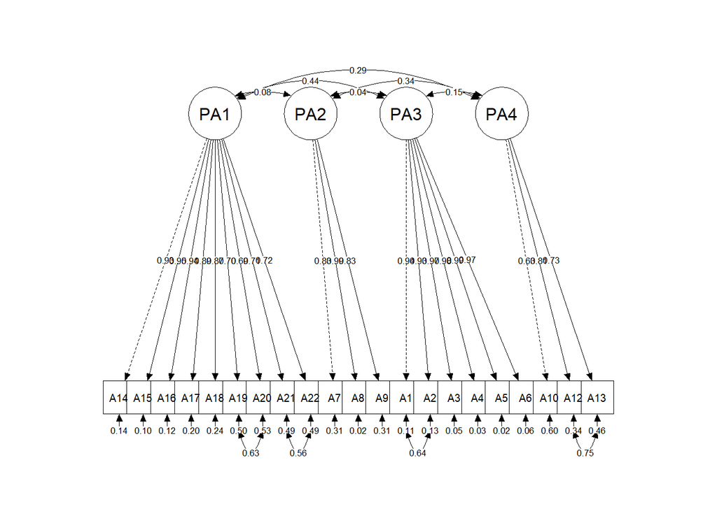

```r
semPaths(cfa.model6, 'path', 'std', style = 'lisrel',
         edge.color = 'black')
```